# Case 31: Measurement Model Assessment

- Show All Code
- Hide All Code
- View Source

Employees Federal Credit Union · M13 study note

Author

Simran Kaur

Published

November 26, 2026

# 1 Purpose and Case Context

Case 31 looks at member opinions of the Employees Federal Credit Union (CU). I use CFA to check two multi-item constructs:

- **Employee proficiencies:** Q3–Q6.
- **Operational effectiveness:** Q9r–Q12r and Q31–Q34.

This is **Step 1 (M13)** of the two-step SEM approach (Anderson & Gerbing, 1988). I assess measurement quality before testing structural hypotheses in **Step 2 (M15)**.

# 2 CFA Learning Notes

| Concept | My understanding |
| --- | --- |
| Latent vs. observed | A construct is inferred from measured survey items. |
| Single vs. multi-item | Single items enter the model as observed measures here. |
| Reflective vs. formative | Reflective items represent a common factor; formative items build a construct. |
| EFA vs. CFA | EFA explores structure; CFA tests a specified structure. |
| Identification | Compare known moments with free parameters; also check identification conditions. |
| Loading and R² | A standardized loading of .90 explains 81% of item variance. |

| Assessment | Guideline |
| --- | --- |
| Model fit | CFI/TLI ≥ .95 preferred; ≥ .90 marginal; RMSEA ≤ .08; SRMR < .08; consider χ². |
| Loadings | ≥ .70 strong; .50 minimum guideline. |
| Reliability | Cronbach’s α and CR ≥ .70. |
| Convergent validity | AVE ≥ .50. |
| Discriminant validity | √AVE > absolute factor correlation; HTMT < .85. |

I look at the overall evidence, not one cutoff alone.

# 3 Case 31 Constructs and Indicators

**Packages**

```r
library(haven)     # read SPSS .sav files
library(dplyr)     # data wrangling
library(tidyr)     # reshaping
library(ggplot2)   # plots
library(lavaan)    # CFA
library(semTools)  # composite reliability, AVE, HTMT
library(semPlot)   # path diagram
library(psych)     # Cronbach's alpha, descriptives
library(knitr)     # tables
```

**R code**

```r
constructs <- tibble(
  Construct = c(rep("Employee Proficiencies", 4), rep("Operational Effectiveness", 8)),
  Item = c("Q3", "Q4", "Q5", "Q6", "Q9r", "Q10r", "Q11r", "Q12r", "Q31", "Q32", "Q33", "Q34"),
  Content = c("Employees are courteous", "Employees are helpful",
              "Employees are professional", "Employees are available",
              "How often statements are received", "Statement accuracy",
              "Statements easy to understand?", "Accounts kept confidential?",
              "Personnel keep my financial info confidential",
              "CU is prompt in processing loan applications",
              "CU's financial services meet members' needs",
              "Loan applications simple and easy to complete"),
  `Response format` = c(rep("5-pt agreement", 4), "5-pt frequency (bipolar)",
                        "4-pt rating", "Yes/No", "Yes/No", rep("5-pt agreement", 4))
)
kable(constructs)
```

Table 1: Constructs and indicators in the hypothesized measurement model

| Construct | Item | Content | Response format |
| --- | --- | --- | --- |
| Employee Proficiencies | Q3 | Employees are courteous | 5-pt agreement |
| Employee Proficiencies | Q4 | Employees are helpful | 5-pt agreement |
| Employee Proficiencies | Q5 | Employees are professional | 5-pt agreement |
| Employee Proficiencies | Q6 | Employees are available | 5-pt agreement |
| Operational Effectiveness | Q9r | How often statements are received | 5-pt frequency (bipolar) |
| Operational Effectiveness | Q10r | Statement accuracy | 4-pt rating |
| Operational Effectiveness | Q11r | Statements easy to understand? | Yes/No |
| Operational Effectiveness | Q12r | Accounts kept confidential? | Yes/No |
| Operational Effectiveness | Q31 | Personnel keep my financial info confidential | 5-pt agreement |
| Operational Effectiveness | Q32 | CU is prompt in processing loan applications | 5-pt agreement |
| Operational Effectiveness | Q33 | CU’s financial services meet members’ needs | 5-pt agreement |
| Operational Effectiveness | Q34 | Loan applications simple and easy to complete | 5-pt agreement |

Other constructs, including Q37, Q13–Q26, Q30 and Q38, enter as observed variables where appropriate. The operational items cover different topics and four response formats, which may weaken their common factor.

# 4 Data Preparation and Reverse Coding

## 4.1 Import and inspect

**R code**

```r
raw <- read_sav("Case 31 Data_efcu_4.sav")

dim(raw)                         # observations and variables
```

```
[1] 128  53
```

**R code**

```r
names(raw)[1:32]                 # original item names are lower case (q3, q4, ...)
```

```
 [1] "q3"  "q4"  "q5"  "q6"  "q7"  "q8"  "q9"  "q10" "q11" "q12" "q13" "q14"
[13] "q15" "q16" "q17" "q18" "q19" "q20" "q21" "q22" "q23" "q24" "q25" "q26"
[25] "q27" "q30" "q31" "q32" "q33" "q34" "q37" "q38"
```

**R code**

```r
sapply(raw[c("q3", "q9", "q10", "q11", "q12", "q31")], class)
```

```
     q3               q9               q10              q11
[1,] "haven_labelled" "haven_labelled" "haven_labelled" "haven_labelled"
[2,] "vctrs_vctr"     "vctrs_vctr"     "vctrs_vctr"     "vctrs_vctr"
[3,] "double"         "double"         "double"         "double"
     q12              q31
[1,] "haven_labelled" "haven_labelled"
[2,] "vctrs_vctr"     "vctrs_vctr"
[3,] "double"         "double"
```

The file has **128 members** and 53 variables. Items are stored as labelled numerics with lower-case names (`q3`, not `Q3`). The file already contains `q9_r` and `q10_r` from earlier data preparation.

**R code**

```r
lab_text <- function(v) {
  l <- attr(raw[[v]], "labels")
  if (is.null(l)) "(no labels)" else paste(paste0(l, " = ", names(l)), collapse = "; ")
}
tibble(Item = c("q3–q6, q31–q34", "q9", "q10", "q11", "q12"),
       Coding = c(lab_text("q3"), lab_text("q9"), lab_text("q10"), lab_text("q11"), lab_text("q12"))) |>
  kable(caption = "Original value labels")
```

Original value labels

| Item | Coding |
| --- | --- |
| q3–q6, q31–q34 | 1 = Strongly Disagree; 2 = Disagree; 3 = Uncertain; 4 = Agree; 5 = Strongly Agree |
| q9 | 1 = Too Often; 2 = Very Often; 3 = About Right; 4 = Not Often Enough; 5 = Never |
| q10 | 1 = Excellent; 2 = Good; 3 = Fair; 4 = Poor |
| q11 | 1 = Yes; 2 = No |
| q12 | 1 = Yes; 2 = No |

## 4.2 Cleaning decisions

- **Q3–Q6, Q31–Q34:** higher = more favorable; keep as is.
- **Q10–Q12:** reverse score so higher means more favorable.
- **Q12:** code 3 (22 no-answer responses) becomes missing.

**R code**

```r
d <- raw |>
  zap_labels() |>
  mutate(
    q12  = na_if(q12, 3),         # "No answer" -> missing
    Q9r  = q9_r,                  # existing variable, verified below
    Q10r = q10_r,                 # existing: 5 - q10 (1 = Poor ... 4 = Excellent)
    Q11r = 3 - q11,               # new: 1 = No, 2 = Yes
    Q12r = 3 - q12                # new: 1 = No, 2 = Yes
  ) |>
  rename(Q3 = q3, Q4 = q4, Q5 = q5, Q6 = q6,
         Q31 = q31, Q32 = q32, Q33 = q33, Q34 = q34)

items    <- c("Q3", "Q4", "Q5", "Q6", "Q9r", "Q10r", "Q11r", "Q12r",
              "Q31", "Q32", "Q33", "Q34")
ep_items <- items[1:4]
oe_items <- items[5:12]
```

## 4.3 Verify reverse coding

Q9r was already prepared, so I check it rather than reverse it again.

**R code**

```r
table(original_q9 = raw$q9, q9_r = raw$q9_r)
```

**R code**

```r
all(raw$q9_r == 6 - raw$q9)   # confirms q9_r = 6 - q9
```

Table 2: Verification of Q9 reverse coding (rows = original q9, columns = q9_r)

```
           q9_r
original_q9  2  3
          3  0 99
          4 29  0
```

```
[1] TRUE
```

**R code**

```r
bind_rows(
  count(d, original = q10, recoded = Q10r) |> mutate(Item = "Q10 → Q10r"),
  count(d, original = q11, recoded = Q11r) |> mutate(Item = "Q11 → Q11r"),
  count(d, original = q12, recoded = Q12r) |> mutate(Item = "Q12 → Q12r")
) |> select(Item, original, recoded, n) |> kable()
```

Table 3: Verification of Q10r, Q11r and Q12r

| Item | original | recoded | n |
| --- | --- | --- | --- |
| Q10 → Q10r | 1 | 4 | 68 |
| Q10 → Q10r | 2 | 3 | 54 |
| Q10 → Q10r | 3 | 2 | 4 |
| Q10 → Q10r | 4 | 1 | 2 |
| Q11 → Q11r | 1 | 2 | 125 |
| Q11 → Q11r | 2 | 1 | 3 |
| Q12 → Q12r | 1 | 2 | 74 |
| Q12 → Q12r | 2 | 1 | 32 |
| Q12 → Q12r | NA | NA | 22 |

Q9r = 6 − Q9. Only “about right” and “not often enough” occur in this sample. **Note:** Q9 is bipolar, so a future sample should use about right vs. not about right rather than simple reversal.

## 4.4 Missing values and descriptives

**R code**

```r
d |>
  select(all_of(items)) |>
  pivot_longer(everything(), names_to = "Item") |>
  group_by(Item = factor(Item, levels = items)) |>
  summarise(Missing = sum(is.na(value)),
            Min = min(value, na.rm = TRUE), Max = max(value, na.rm = TRUE),
            Mean = mean(value, na.rm = TRUE), SD = sd(value, na.rm = TRUE),
            Skew = psych::skew(value, na.rm = TRUE)) |>
  kable(digits = 2)
```

Table 4: Missing values and descriptive statistics for the CFA indicators

| Item | Missing | Min | Max | Mean | SD | Skew |
| --- | --- | --- | --- | --- | --- | --- |
| Q3 | 0 | 3 | 5 | 4.35 | 0.66 | -0.51 |
| Q4 | 0 | 2 | 5 | 4.31 | 0.70 | -0.64 |
| Q5 | 0 | 3 | 5 | 4.08 | 0.66 | -0.08 |
| Q6 | 0 | 2 | 5 | 4.08 | 0.79 | -0.52 |
| Q9r | 0 | 2 | 3 | 2.77 | 0.42 | -1.29 |
| Q10r | 0 | 1 | 4 | 3.47 | 0.64 | -1.14 |
| Q11r | 0 | 1 | 2 | 1.98 | 0.15 | -6.23 |
| Q12r | 22 | 1 | 2 | 1.70 | 0.46 | -0.85 |
| Q31 | 0 | 1 | 5 | 3.95 | 0.68 | -0.53 |
| Q32 | 0 | 2 | 5 | 3.72 | 0.79 | -0.03 |
| Q33 | 0 | 2 | 5 | 3.59 | 0.68 | -0.34 |
| Q34 | 0 | 1 | 5 | 3.46 | 0.78 | -0.90 |

**R code**

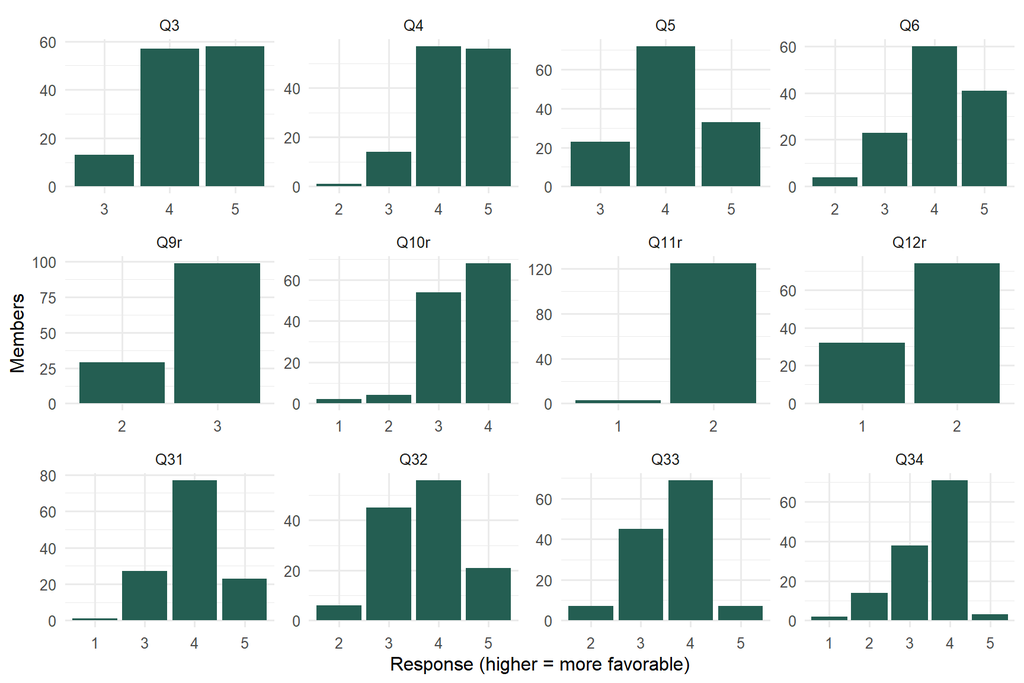

Figure 1: Response distributions for the 12 CFA indicators

```r
d |>
  select(all_of(items)) |>
  pivot_longer(everything(), names_to = "Item") |>
  filter(!is.na(value)) |>
  mutate(Item = factor(Item, levels = items)) |>
  ggplot(aes(factor(value))) +
  geom_bar(fill = "#245e52") +
  facet_wrap(~Item, scales = "free", ncol = 4) +
  labs(x = "Response (higher = more favorable)", y = "Members") +
  theme_minimal(base_size = 12)
```

- **Missing data:** Q12r has 22 missing responses. FIML retains available information under its missing-data assumptions.
- **Q11r:** almost constant; limited variance.
- **Operational items:** mixed binary, four-point and five-point scales.
- **Employee items:** responses cluster at 4 and 5.

**R code**

```r
round(cor(d[items], use = "pairwise.complete.obs"), 2) |> kable()
```

Table 5: Item correlations (pairwise)

|  | Q3 | Q4 | Q5 | Q6 | Q9r | Q10r | Q11r | Q12r | Q31 | Q32 | Q33 | Q34 |
| --- | --- | --- | --- | --- | --- | --- | --- | --- | --- | --- | --- | --- |
| Q3 | 1.00 | 0.72 | 0.57 | 0.46 | 0.06 | 0.09 | 0.08 | 0.08 | 0.22 | 0.21 | 0.20 | -0.01 |
| Q4 | 0.72 | 1.00 | 0.68 | 0.67 | 0.03 | 0.18 | 0.14 | 0.09 | 0.29 | 0.39 | 0.30 | 0.08 |
| Q5 | 0.57 | 0.68 | 1.00 | 0.64 | 0.15 | 0.19 | 0.10 | 0.10 | 0.22 | 0.33 | 0.42 | 0.02 |
| Q6 | 0.46 | 0.67 | 0.64 | 1.00 | 0.22 | 0.16 | 0.28 | 0.04 | 0.23 | 0.43 | 0.41 | 0.07 |
| Q9r | 0.06 | 0.03 | 0.15 | 0.22 | 1.00 | 0.22 | 0.29 | 0.02 | -0.04 | 0.07 | 0.17 | 0.06 |
| Q10r | 0.09 | 0.18 | 0.19 | 0.16 | 0.22 | 1.00 | 0.36 | 0.18 | 0.08 | 0.23 | 0.21 | 0.08 |
| Q11r | 0.08 | 0.14 | 0.10 | 0.28 | 0.29 | 0.36 | 1.00 | 0.06 | -0.01 | 0.08 | 0.14 | 0.09 |
| Q12r | 0.08 | 0.09 | 0.10 | 0.04 | 0.02 | 0.18 | 0.06 | 1.00 | -0.16 | -0.13 | -0.24 | 0.05 |
| Q31 | 0.22 | 0.29 | 0.22 | 0.23 | -0.04 | 0.08 | -0.01 | -0.16 | 1.00 | 0.28 | 0.12 | 0.00 |
| Q32 | 0.21 | 0.39 | 0.33 | 0.43 | 0.07 | 0.23 | 0.08 | -0.13 | 0.28 | 1.00 | 0.22 | 0.39 |
| Q33 | 0.20 | 0.30 | 0.42 | 0.41 | 0.17 | 0.21 | 0.14 | -0.24 | 0.12 | 0.22 | 1.00 | 0.04 |
| Q34 | -0.01 | 0.08 | 0.02 | 0.07 | 0.06 | 0.08 | 0.09 | 0.05 | 0.00 | 0.39 | 0.04 | 1.00 |

Employee items correlate .46–.72; operational items mostly range from −.24 to .39. Q12r correlates negatively with Q31–Q33.

# 5 Hypothesized Measurement Model

**R code**

```r
measurement_model <- '
  Employee_Proficiencies    =~ Q3 + Q4 + Q5 + Q6
  Operational_Effectiveness =~ Q9r + Q10r + Q11r + Q12r + Q31 + Q32 + Q33 + Q34
'
```

The two factors are allowed to correlate: employee proficiencies measures people, while operational effectiveness measures systems and processes.

**Identification:**

**R code**

```r
p     <- length(items)                     # observed indicators
known <- p * (p + 1) / 2                   # unique variances and covariances
free  <- (12 - 2) + 12 + 2 + 1             # free loadings + residuals + factor variances + covariance
c(indicators = p, known_values = known, free_parameters = free, df = known - free)
```

```
     indicators    known_values free_parameters              df
             12              78              25              53
```

- 78 known covariance moments; 25 free covariance parameters.
- **df = 53:** over-identified model, with testable fit.

# 6 R/lavaan Analysis

**R code**

```r
fit <- cfa(measurement_model, data = d,
           estimator = "ML",     # maximum likelihood, as in class
           missing   = "fiml")   # keep all 128 members
summary(fit, fit.measures = TRUE, standardized = TRUE, rsquare = TRUE)
```

```
lavaan 0.7-3 ended normally after 110 iterations

  Estimator                                         ML
  Optimization method                           NLMINB
  Number of model parameters                        37

  Number of observations                           128
  Number of missing patterns                         2

Model Test User Model:

  Test statistic                               128.253
  Degrees of freedom                                53
  P-value (Chi-square)                           0.000

  Browne's residual (NT model-based) test
  Test statistic                                80.292
  Degrees of freedom                                53
  P-value (Chi-square)                           0.009

Model Test Baseline Model:

  Test statistic                               466.932
  Degrees of freedom                                66
  P-value                                        0.000

User Model versus Baseline Model:

  Comparative Fit Index (CFI)                    0.812
  Tucker-Lewis Index (TLI)                       0.766

  Robust Comparative Fit Index (CFI)             0.808
  Robust Tucker-Lewis Index (TLI)                0.761

Loglikelihood and Information Criteria:

  Loglikelihood user model (H0)              -1138.395
  Loglikelihood unrestricted model (H1)      -1074.268

  Akaike (AIC)                                2350.790
```

[output cut: 108 more lines]

```

R-Square:
                   Estimate
    Q3                0.546
    Q4                0.828
    Q5                0.602
    Q6                0.562
    Q9r               0.050
    Q10r              0.154
    Q11r              0.082
    Q12r              0.006
    Q31               0.121
    Q32               0.398
    Q33               0.221
    Q34               0.078
```

ML is used first; robust ML is checked later because several indicators are binary or skewed.

# 7 CFA Results

## 7.1 Model identification

**R code**

```r
c(converged          = lavInspect(fit, "converged"),
  free_parameters    = fitMeasures(fit, "npar") - length(items),  # minus 12 means added by FIML
  df                 = fitMeasures(fit, "df"),
  negative_variances = any(lavInspect(fit, "est")$theta |> diag() < 0))
```

```
           converged free_parameters.npar                df.df
                   1                   25                   53
  negative_variances
                   0
```

The model converged with **53 df**, matching the hand calculation. No negative residual variances were reported.

## 7.2 Model fit

**R code**

```r
fm <- fitMeasures(fit, c("chisq", "df", "pvalue", "cfi", "tli",
                         "rmsea", "rmsea.ci.lower", "rmsea.ci.upper", "srmr"))
tibble(
  Index = c("χ²(df)", "CFI", "TLI", "RMSEA [90% CI]", "SRMR"),
  Value = c(sprintf("%.2f (%d), p %s", fm["chisq"], as.integer(fm["df"]),
                    ifelse(fm["pvalue"] < .001, "< .001", sprintf("= %.3f", fm["pvalue"]))),
            sprintf("%.3f", fm["cfi"]), sprintf("%.3f", fm["tli"]),
            sprintf("%.3f [%.3f, %.3f]", fm["rmsea"], fm["rmsea.ci.lower"], fm["rmsea.ci.upper"]),
            sprintf("%.3f", fm["srmr"])),
  Guideline = c("p > .05", "≥ .95 (≥ .90 marginal)", "≥ .95 (≥ .90 marginal)",
                "≤ .08", "< .08"),
  Verdict = c(ifelse(fm["pvalue"] > .05, "Pass", "Fail"),
              ifelse(fm["cfi"] >= .95, "Pass", ifelse(fm["cfi"] >= .90, "Marginal", "Fail")),
              ifelse(fm["tli"] >= .95, "Pass", ifelse(fm["tli"] >= .90, "Marginal", "Fail")),
              ifelse(fm["rmsea"] <= .08, "Pass", "Fail"),
              ifelse(fm["srmr"] < .08, "Pass", "Fail"))
) |> kable()
```

Table 6: Global fit of the hypothesized two-factor model

| Index | Value | Guideline | Verdict |
| --- | --- | --- | --- |
| χ²(df) | 128.25 (53), p < .001 | p > .05 | Fail |
| CFI | 0.812 | ≥ .95 (≥ .90 marginal) | Fail |
| TLI | 0.766 | ≥ .95 (≥ .90 marginal) | Fail |
| RMSEA [90% CI] | 0.105 [0.082, 0.129] | ≤ .08 | Fail |
| SRMR | 0.086 | < .08 | Fail |

**Decision:** Poor fit across all five indices. CFI and TLI are below .90, and the RMSEA interval is above .08.

## 7.3 Standardized loadings

**R code**

```r
strength <- function(x) cut(abs(x), c(-Inf, .40, .50, .60, .70, Inf), right = FALSE,
  labels = c("Very weak", "Weak", "Moderate", "Moderate to strong", "Strong"))

loadings <- standardizedSolution(fit) |>
  filter(op == "=~") |>
  transmute(Factor = ifelse(lhs == "Employee_Proficiencies", "Employee Prof.", "Operational Eff."),
            Item = rhs, Loading = est.std, SE = se,
            p = ifelse(pvalue < .001, "< .001", sprintf("%.3f", pvalue)),
            R2 = est.std^2,
            Strength = ifelse(est.std < 0, "Wrong sign", as.character(strength(est.std))))
kable(loadings, digits = 2)
```

Table 7: Standardized factor loadings (Std.all) and R²

| Factor | Item | Loading | SE | p | R2 | Strength |
| --- | --- | --- | --- | --- | --- | --- |
| Employee Prof. | Q3 | 0.74 | 0.05 | < .001 | 0.55 | Strong |
| Employee Prof. | Q4 | 0.91 | 0.03 | < .001 | 0.83 | Strong |
| Employee Prof. | Q5 | 0.78 | 0.04 | < .001 | 0.60 | Strong |
| Employee Prof. | Q6 | 0.75 | 0.05 | < .001 | 0.56 | Strong |
| Operational Eff. | Q9r | 0.22 | 0.11 | 0.041 | 0.05 | Very weak |
| Operational Eff. | Q10r | 0.39 | 0.10 | < .001 | 0.15 | Very weak |
| Operational Eff. | Q11r | 0.29 | 0.11 | 0.009 | 0.08 | Very weak |
| Operational Eff. | Q12r | -0.08 | 0.13 | 0.544 | 0.01 | Wrong sign |
| Operational Eff. | Q31 | 0.35 | 0.10 | < .001 | 0.12 | Very weak |
| Operational Eff. | Q32 | 0.63 | 0.10 | < .001 | 0.40 | Moderate to strong |
| Operational Eff. | Q33 | 0.47 | 0.10 | < .001 | 0.22 | Weak |
| Operational Eff. | Q34 | 0.28 | 0.11 | 0.014 | 0.08 | Very weak |

**R code**

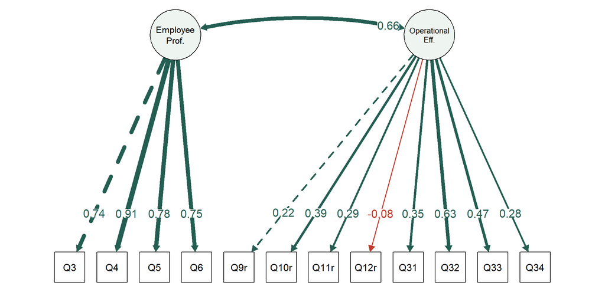

Figure 2: Standardized two-factor CFA solution (red = negative loading; dashed = loading fixed to 1 for scaling)

```r
semPaths(fit, what = "std", whatLabels = "std", layout = "tree2", rotation = 1,
         edge.label.cex = 1, edge.label.position = 0.8, fade = FALSE,
         posCol = "#245e52", negCol = "#c0392b",
         sizeMan = 6, sizeLat = 10, nCharNodes = 0,
         nodeLabels = c(items, "Employee\nProf.", "Operational\nEff."),
         residuals = FALSE, intercepts = FALSE,
         color = list(lat = "#eef5f1", man = "white"), mar = c(3, 3, 3, 3))
```

- **Employee proficiencies:** all four loadings ≥ .70; Q4 is strongest.
- **Operational effectiveness:** only Q32 reaches .50; Q12r loads negatively.
- Statistical significance alone does not establish strong measurement.

## 7.4 Reliability and convergent validity

**R code**

```r
alpha_ep <- psych::alpha(d[ep_items])$total$raw_alpha
alpha_oe <- psych::alpha(d[oe_items], check.keys = FALSE, warnings = FALSE)$total$raw_alpha
cr  <- compRelSEM(fit)   # composite reliability (omega)
ave <- AVE(fit)

rel <- tibble(
  Construct = c("Employee Proficiencies", "Operational Effectiveness"),
  Items = c(4, 8),
  `Cronbach's α` = c(alpha_ep, alpha_oe),
  `Composite reliability` = as.numeric(cr),
  AVE = as.numeric(ave),
  `√AVE` = sqrt(as.numeric(ave))
)
kable(rel, digits = 3)
```

Table 8: Internal consistency and convergent validity

| Construct | Items | Cronbach’s α | Composite reliability | AVE | √AVE |
| --- | --- | --- | --- | --- | --- |
| Employee Proficiencies | 4 | 0.866 | 0.877 | 0.633 | 0.795 |
| Operational Effectiveness | 8 | 0.458 | 0.529 | 0.178 | 0.422 |

Employee proficiencies passes reliability and AVE guidelines, consistent with my earlier EFA. Operational effectiveness fails both; its AVE is only 0.18.

## 7.5 Discriminant validity

**R code**

```r
phi  <- lavInspect(fit, "cor.lv")[1, 2]
htmt_val <- htmt(measurement_model, d[items])[2, 1]

tibble(
  Check = c("Latent factor correlation (φ)",
            "√AVE Employee Proficiencies > φ ?",
            "√AVE Operational Effectiveness > φ ?",
            "HTMT ratio < .85 ?"),
  Value = sprintf("%.3f", c(phi, sqrt(ave[1]), sqrt(ave[2]), htmt_val)),
  Result = c("Moderate–strong positive",
             ifelse(sqrt(ave[1]) > phi, "Yes", "No"),
             ifelse(sqrt(ave[2]) > phi, "Yes", "No"),
             ifelse(htmt_val < .85, "Yes", "No"))
) |> kable()
```

Table 9: Discriminant validity: factor correlation, Fornell–Larcker and HTMT

| Check | Value | Result |
| --- | --- | --- |
| Latent factor correlation (φ) | 0.662 | Moderate–strong positive |
| √AVE Employee Proficiencies > φ ? | 0.795 | Yes |
| √AVE Operational Effectiveness > φ ? | 0.422 | No |
| HTMT ratio < .85 ? | 0.517 | Yes |

HTMT is below .85. Fornell–Larcker passes for employee proficiencies but fails for operational effectiveness because its AVE is low. Discriminant validity is therefore not fully established.

## 7.6 Possible model problems

### 7.6.1 Modification indices

**R code**

```r
modindices(fit, sort. = TRUE, maximum.number = 10) |>
  select(lhs, op, rhs, mi, sepc.all) |>
  kable(digits = 2)
```

Table 10: Ten largest modification indices (diagnostic only; not added to the model)

|  | lhs | op | rhs | mi | sepc.all |
| --- | --- | --- | --- | --- | --- |
| 54 | Q3 | ~~ | Q4 | 18.00 | 0.83 |
| 118 | Q32 | ~~ | Q34 | 16.80 | 0.46 |
| 99 | Q10r | ~~ | Q11r | 11.48 | 0.32 |
| 53 | Operational_Effectiveness | =~ | Q6 | 9.99 | 0.41 |
| 56 | Q3 | ~~ | Q6 | 9.09 | -0.34 |
| 93 | Q9r | ~~ | Q11r | 7.79 | 0.26 |
| 67 | Q4 | ~~ | Q9r | 7.66 | -0.34 |
| 82 | Q5 | ~~ | Q33 | 7.57 | 0.28 |
| 112 | Q12r | ~~ | Q33 | 7.32 | -0.28 |
| 50 | Operational_Effectiveness | =~ | Q3 | 7.07 | -0.35 |

The indices suggest shared wording (Q3–Q4), loan and statement item clusters, and a possible Q6 cross-loading. I do not add paths just to improve fit.

### 7.6.2 Q12 vs. Q31

Both ask about confidentiality, but their responses disagree.

**R code**

```r
d |>
  filter(!is.na(q12)) |>
  mutate(Q12 = ifelse(q12 == 1, "Yes", "No")) |>
  group_by(Q12) |>
  summarise(n = n(), `% agree or strongly agree on Q31` = 100 * mean(Q31 >= 4)) |>
  kable(digits = 1)
```

Table 11: Q12 by Q31: share of members agreeing that personnel keep information confidential

| Q12 | n | % agree or strongly agree on Q31 |
| --- | --- | --- |
| No | 32 | 84.4 |
| Yes | 74 | 75.7 |

Q12 responses run opposite to Q31. I retain the coding for now and flag it for verification against the questionnaire.

### 7.6.3 Alternative model

I test a three-factor model based on item content and response format: employee proficiencies, **Statements** (Q9r–Q12r), and **Service Operations** (Q31–Q34).

**R code**

```r
alt_model <- '
  Employee_Proficiencies =~ Q3 + Q4 + Q5 + Q6
  Statements             =~ Q9r + Q10r + Q11r + Q12r
  Service_Operations     =~ Q31 + Q32 + Q33 + Q34
'
fit_alt <- cfa(alt_model, data = d, estimator = "ML", missing = "fiml")
```

**R code**

```r
idx <- c("chisq", "df", "cfi", "tli", "rmsea", "srmr", "aic", "bic")
cmp <- rbind(`Hypothesized (2 factors)` = fitMeasures(fit, idx),
             `Alternative A (3 factors)` = fitMeasures(fit_alt, idx))
kable(cmp, digits = 3)
lrt <- anova(fit_alt, fit)
lrt
```

```
Chi-Squared Difference Test

        Df    AIC    BIC  Chisq Chisq diff Df diff Pr(>Chisq)
fit_alt 51 2333.3 2444.6 106.79
fit     53 2350.8 2456.3 128.25     21.458       2   2.19e-05 ***
---
Signif. codes:  0 '***' 0.001 '**' 0.01 '*' 0.05 '.' 0.1 ' ' 1
```

Table 12: Hypothesized model vs. Alternative Model A

|  | chisq | df | cfi | tli | rmsea | srmr | aic | bic |
| --- | --- | --- | --- | --- | --- | --- | --- | --- |
| Hypothesized (2 factors) | 128.253 | 53 | 0.812 | 0.766 | 0.105 | 0.086 | 2350.790 | 2456.315 |
| Alternative A (3 factors) | 106.795 | 51 | 0.861 | 0.820 | 0.092 | 0.080 | 2333.331 | 2444.561 |

**R code**

```r
standardizedSolution(fit_alt) |>
  filter((op == "=~" & lhs != "Employee_Proficiencies") | (op == "~~" & lhs != rhs)) |>
  transmute(Parameter = paste(lhs, op, rhs), Estimate = est.std,
            p = ifelse(pvalue < .001, "< .001", sprintf("%.3f", pvalue))) |>
  kable(digits = 2)
alt_ave <- AVE(fit_alt); alt_cr <- compRelSEM(fit_alt)
```

Table 13: Alternative Model A: standardized loadings for the operational items and factor correlations

| Parameter | Estimate | p |
| --- | --- | --- |
| Statements =~ Q9r | 0.39 | < .001 |
| Statements =~ Q10r | 0.65 | < .001 |
| Statements =~ Q11r | 0.57 | < .001 |
| Statements =~ Q12r | 0.18 | 0.200 |
| Service_Operations =~ Q31 | 0.36 | 0.001 |
| Service_Operations =~ Q32 | 0.76 | < .001 |
| Service_Operations =~ Q33 | 0.37 | 0.033 |
| Service_Operations =~ Q34 | 0.36 | 0.020 |
| Employee_Proficiencies ~~ Statements | 0.31 | 0.008 |
| Employee_Proficiencies ~~ Service_Operations | 0.59 | 0.003 |
| Statements ~~ Service_Operations | 0.33 | 0.055 |

The ML comparison favors the split, but both models fit poorly and the new operational factors have weak AVE. The items may function more like a checklist of service features than one reflective construct. The difference-test result should be treated cautiously because the merged-factor restriction is nonregular.

## 7.7 Robust estimation

I repeat both models using MLR to check sensitivity to non-normality.

**R code**

```r
fit_r     <- cfa(measurement_model, d, estimator = "MLR", missing = "fiml")
fit_alt_r <- cfa(alt_model,         d, estimator = "MLR", missing = "fiml")
ridx <- c("chisq.scaled", "df", "cfi.robust", "tli.robust", "rmsea.robust", "srmr")
rbind(Hypothesized = fitMeasures(fit_r, ridx),
      `Alternative A` = fitMeasures(fit_alt_r, ridx)) |> kable(digits = 3)
lrt_r <- lavTestLRT(fit_alt_r, fit_r)
```

Table 14: Robust (MLR) fit for both models

[output not shown]

Both models still fit poorly; employee proficiencies remains strong.

With MLR, 4 operational loadings are no longer significant. The scaled difference test is not significant (*p* = 0.212).

# 8 Final Measurement Model for M15

I keep employee proficiencies as a latent factor and assess which operational item can serve as an observed measure.

## 8.1 Item selection

**R code**

```r
oe_model <- 'Operational_Effectiveness =~ Q9r + Q10r + Q11r + Q12r + Q31 + Q32 + Q33 + Q34'
fit_oe <- cfa(oe_model, data = d, estimator = "ML", missing = "fiml")
```

**R code**

```r
one_l <- standardizedSolution(fit_oe) |> filter(op == "=~") |>
  select(Item = rhs, `One-factor` = est.std)
sel <- oe_l |> select(Item, `Two-factor` = Loading) |>
  left_join(one_l, by = "Item") |>
  mutate(`Rank (two-factor)` = rank(-`Two-factor`), `Rank (one-factor)` = rank(-`One-factor`),
         Content = constructs$Content[match(Item, constructs$Item)])
kable(sel, digits = 2)
one_fm <- fitMeasures(fit_oe, c("cfi", "rmsea"))
```

Table 15: Standardized loadings of the operational items in the two-factor and one-factor models

| Item | Two-factor | One-factor | Rank (two-factor) | Rank (one-factor) | Content |
| --- | --- | --- | --- | --- | --- |
| Q9r | 0.22 | 0.38 | 7 | 4 | How often statements are received |
| Q10r | 0.39 | 0.60 | 3 | 1 | Statement accuracy |
| Q11r | 0.29 | 0.48 | 5 | 2 | Statements easy to understand? |
| Q12r | -0.08 | 0.01 | 8 | 8 | Accounts kept confidential? |
| Q31 | 0.35 | 0.16 | 4 | 7 | Personnel keep my financial info confidential |
| Q32 | 0.63 | 0.42 | 1 | 3 | CU is prompt in processing loan applications |
| Q33 | 0.47 | 0.37 | 2 | 5 | CU’s financial services meet members’ needs |
| Q34 | 0.28 | 0.27 | 6 | 6 | Loan applications simple and easy to complete |

- **Q32:** strongest operational loading in the original two-factor model; directly measures prompt loan processing.
- **Q10r:** strongest in the one-factor model, but mainly represents statement accuracy.
- **Q11r:** almost constant.

Q32 is the best compromise based on item meaning and loadings, not a complete measure of operational effectiveness.

## 8.2 Two-item alternatives

**R code**

```r
pair_fit <- function(pair) {
  m <- paste0('Employee_Proficiencies =~ Q3 + Q4 + Q5 + Q6\n',
              'Operational_Effectiveness =~ ', paste(pair, collapse = " + "))
  f <- cfa(m, data = d, estimator = "ML", missing = "fiml")
  ss <- standardizedSolution(f)
  ld <- ss |> filter(op == "=~", lhs == "Operational_Effectiveness")
  tibble(Pair = paste(pair, collapse = " + "),
         Loadings = paste(sprintf("%.2f", ld$est.std), collapse = ", "),
         AVE = AVE(f)[["Operational_Effectiveness"]],
         `Factor r` = lavInspect(f, "cor.lv")[1, 2],
         `Admissible?` = ifelse(any(diag(lavInspect(f, "est")$theta) < 0) |
                                 any(abs(ld$est.std) > 1), "No (Heywood case)", "Yes"))
}
bind_rows(pair_fit(c("Q32", "Q33")), pair_fit(c("Q32", "Q34"))) |> kable(digits = 2)
```

Table 16: Two-item operational factors tested with employee proficiencies

| Pair | Loadings | AVE | Factor r | Admissible? |
| --- | --- | --- | --- | --- |
| Q32 + Q33 | 0.49, 0.46 | 0.23 | 0.87 | Yes |
| Q32 + Q34 | 1.58, 0.25 | 1.30 | 0.27 | No (Heywood case) |

Q32 + Q33 fails validity; Q32 + Q34 produces an inadmissible solution (Heywood case). I retain Q32 alone.

## 8.3 Final specification

**Employee proficiencies:** Q3–Q6 as a latent factor. **Operational effectiveness:** Q32 as a single observed indicator, represented with zero fixed error variance in this CFA.

**R code**

```r
final_model <- '
  Employee_Proficiencies    =~ Q3 + Q4 + Q5 + Q6
  Operational_Effectiveness =~ 1*Q32      # single indicator
  Q32 ~~ 0*Q32                            # treated as observed: no error variance
'
fit_final <- cfa(final_model, data = d, estimator = "ML", missing = "fiml")
```

**R code**

```r
fidx <- c("chisq", "df", "cfi", "tli", "rmsea", "srmr")
rbind(`Hypothesized (12 items)` = fitMeasures(fit, fidx),
      `Final: EP latent + Q32` = fitMeasures(fit_final, fidx)) |> kable(digits = 3)
fin_fm  <- fitMeasures(fit_final, fidx)
fin_phi <- standardizedSolution(fit_final) |>
  filter(op == "~~", lhs == "Employee_Proficiencies", rhs == "Operational_Effectiveness") |>
  pull(est.std)
```

Table 17: Fit of the final Step 1 measurement model compared with the hypothesized model

|  | chisq | df | cfi | tli | rmsea | srmr |
| --- | --- | --- | --- | --- | --- | --- |
| Hypothesized (12 items) | 128.253 | 53 | 0.812 | 0.766 | 0.105 | 0.086 |
| Final: EP latent + Q32 | 19.471 | 5 | 0.950 | 0.900 | 0.150 | 0.045 |

The revised model has better descriptive fit (CFI = 0.95, TLI = 0.90, SRMR = 0.045). RMSEA remains high; low df may contribute. The models use different indicator sets, so this is not a formal nested comparison. The employee factor correlates 0.42 with Q32.

# 9 Reflection and Conclusion

- **Keep:** employee proficiencies (Q3–Q6); strong loadings, reliability and AVE.
- **Revise:** operational effectiveness to Q32 alone for M15, interpreting it specifically as perceived promptness of loan processing.
- **Limitations:** Q32 does not cover all operational features; fixing its error to zero is an assumption. Consider sensitivity to reliability and an ordinal estimator, and check common method bias and Q12 coding.

This analysis helped me understand why a measurement model should be checked before testing relationships between constructs. A significant loading does not automatically mean an item measures the intended construct well.

# References

Anderson, J. C., & Gerbing, D. W. (1988). Structural equation modeling in practice: A review and recommended two-step approach. *Psychological Bulletin, 103*(3), 411–423.

Byrne, B. M. (2016). *Structural equation modeling with AMOS: Basic concepts, applications, and programming* (3rd ed.). Routledge.

Fornell, C., & Larcker, D. F. (1981). Evaluating structural equation models with unobservable variables and measurement error. *Journal of Marketing Research, 18*(1), 39–50.

Hair, J. F., Black, W. C., Babin, B. J., & Anderson, R. E. (2019). *Multivariate data analysis* (8th ed.). Cengage.

Henseler, J., Ringle, C. M., & Sarstedt, M. (2015). A new criterion for assessing discriminant validity in variance-based structural equation modeling. *Journal of the Academy of Marketing Science, 43*(1), 115–135.

Hu, L., & Bentler, P. M. (1999). Cutoff criteria for fit indexes in covariance structure analysis: Conventional criteria versus new alternatives. *Structural Equation Modeling, 6*(1), 1–55.

Kenny, D. A., Kaniskan, B., & McCoach, D. B. (2015). The performance of RMSEA in models with small degrees of freedom. *Sociological Methods & Research, 44*(3), 486–507.

Rosseel, Y. (2012). lavaan: An R package for structural equation modeling. *Journal of Statistical Software, 48*(2), 1–36.

# Appendix: Reproducibility and Publication Links

- **GitHub Repository:** [IBM6500-F26 / M13](https://github.com/Simrank-DM/IBM6500-F26/tree/main/M13)
- **GitHub Pages:** [M13 Measurement Model Assessment Report](https://simrank-dm.github.io/IBM6500-F26/M13/M13-Measurement-Model-Case31-Simran-Kaur.html)

Data: `Case 31 Data_efcu_4.sav`, stored in the same folder as this QMD.